# Netflix

Parth Gandhi

1/5/2022

Loading the required libraries

```r
library(ggplot2)
library(tidyverse)
library(naniar)
library(forcats)
library(wordcloud)
library(tm)
library(SnowballC)
library(RColorBrewer)
library(tidytext)
```

Loading the dataset from kaggle

```r
netflix <- read.csv("netflix_titles.csv")
```

We look at the structure of the data and check if there are missing values present.

```r
summary(netflix)
```

```
##    show_id              type              title             director
##  Length:8807        Length:8807        Length:8807        Length:8807
##  Class :character   Class :character   Class :character   Class :character
##  Mode  :character   Mode  :character   Mode  :character   Mode  :character
##
##
##
##      cast             country           date_added         release_year
##  Length:8807        Length:8807        Length:8807        Min.   :1925
##  Class :character   Class :character   Class :character   1st Qu.:2013
##  Mode  :character   Mode  :character   Mode  :character   Median :2017
##                                                           Mean   :2014
##                                                           3rd Qu.:2019
##                                                           Max.   :2021
##     rating            duration          listed_in         description
##  Length:8807        Length:8807        Length:8807        Length:8807
##  Class :character   Class :character   Class :character   Class :character
##  Mode  :character   Mode  :character   Mode  :character   Mode  :character
##
##
##
```

```r
f = function(x){
  y = any(x == "")
}
check.na = apply(netflix,2,f)
check.na
```

```
##      show_id         type        title     director         cast      country
##        FALSE        FALSE        FALSE         TRUE         TRUE         TRUE
##   date_added release_year       rating     duration    listed_in  description
##         TRUE        FALSE         TRUE         TRUE        FALSE        FALSE
```

We can see that the following variables have missing values: 1. director 2. cast 3. country 4. date_added 5.rating 6. duration

Now we check how many missing values does each column have.

```r
f2 = function(x){
  y = 0
  for(i in 1:nrow(netflix)){
  if(x[i] == ""){
    y = y + 1
  }
    }
  return(sum(y))
}
check.na.sum = apply(netflix,2,f2)
check.na.sum
```

```
##      show_id         type        title     director         cast      country
##            0            0            0         2634          825          831
##   date_added release_year       rating     duration    listed_in  description
##           10            0            4            3            0            0
```

For making plots based on the variables of director, cast and country we will remove those values from our dataset and make the required plots.

We start our data visualization by seeing the proportion of TV Shows and Movies on Netflix.

```r
table(netflix$type)
```

```
##
##   Movie TV Show
##    6131    2676
```

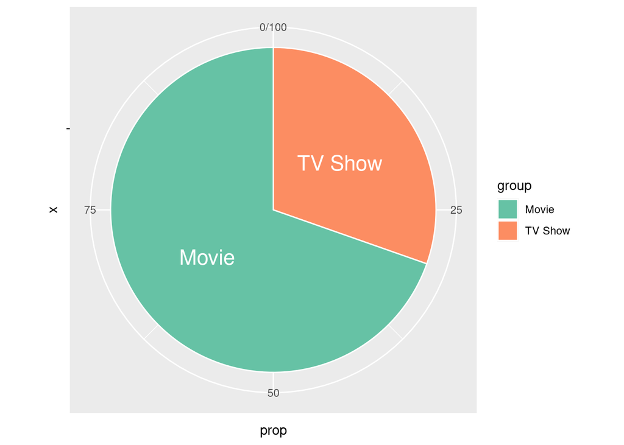

```r
data = data.frame(group = c("Movie", "TV Show"),value= c(6131,2676))

data <- data %>%
  arrange(desc(group)) %>%
  mutate(prop = value / sum(data$value) *100) %>%
  mutate(ypos = cumsum(prop)- 0.5*prop )

# Basic piechart
ggplot(data, aes(x="", y=prop, fill=group)) +
  geom_bar(stat="identity", width=1, color="white") +
  coord_polar("y", start=0) +
  geom_text(aes(y = ypos, label = group), color = "white", size=6) +
  scale_fill_brewer(palette="Set2")
```

```r
100*data$value/sum(data$value)
```

```
## [1] 30.38492 69.61508
```

We can see that majority of the content on Netflix nearly 70% are Movies while the other 30% are TV Shows.

Now we look the distribtuion of content as per the rating given to it which are divided by the type of the content.

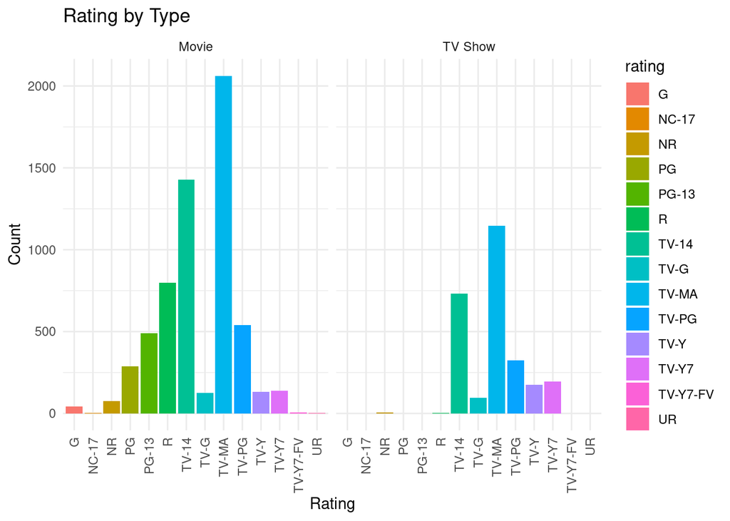

```r
netflix %>%
 filter(!(rating %in% c("74 min", "84 min", "66 min", ""))) %>%
 ggplot() +
  aes(x = rating, fill = rating) +
  geom_bar() +
  scale_fill_hue(direction = 1) +
  labs(x = "Rating", y = "Count", title = "Rating by Type") +
  theme_minimal() +
  facet_wrap(vars(type)) +theme(axis.text.x = element_text(angle = 90, vjust = 0.5, hjust=1))
```

We see that the maximum TV Shows and Movies are rated TV-MA meaning that they are not suitable for minors under 18 years of age.

We look at the distribtuion of hoiw long aTV Show runs for by looking at the number of seasons for that show.

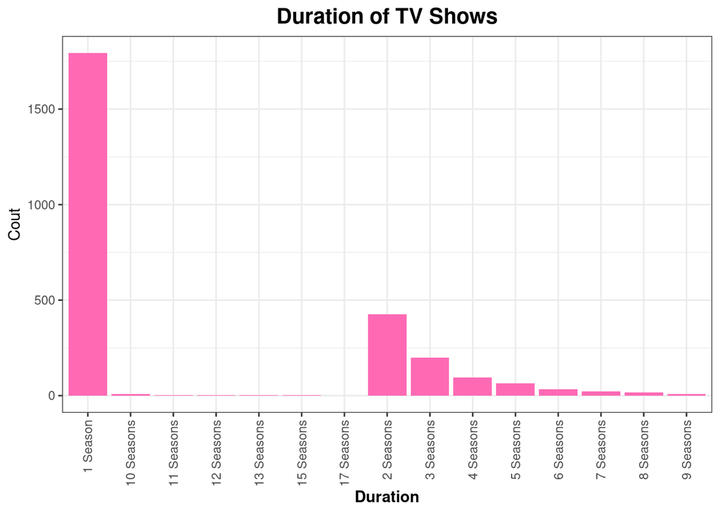

```r
netflix %>%
  filter(type %in% "TV Show") %>%
  ggplot() +
  aes(x = duration,) +
  geom_bar(fill = "#FF69B4") +
  labs(
    x = "Duration",
    y = "Cout",
    title = "Duration of TV Shows"
  ) +
  theme_bw() +
  theme(
    plot.title = element_text(size = 15L,
                              face = "bold",
                              hjust = 0.5),
    axis.title.x = element_text(face = "bold")
  ) + theme(axis.text.x = element_text(angle = 90, vjust = 0.5, hjust=1))
```

We look at the distribution of the titles from the country where it was produced and their origin.

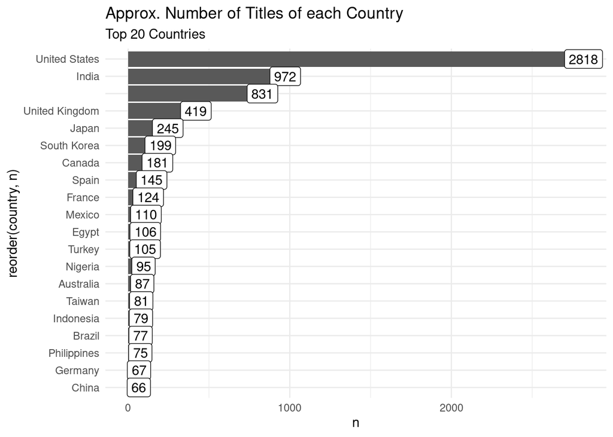

```r
netflix %>%
 filter(!str_detect(country,',')) %>%
 group_by(country) %>%
 count() %>%
 arrange(desc(n)) %>%
 head(20) %>%
 ggplot() + geom_col(aes(y = reorder(country,n), x = n)) +
 geom_label(aes(y = reorder(country,n), x = n, label = n)) +
  labs(title = 'Approx. Number of Titles of each Country',
       subtitle = 'Top 20 Countries') +
theme_minimal()
```

We see that most of the content on Netflix is produced from the USA while India ranks second but the rest of the contries cannot be compareed to USA for their contribtuion on the Content on Netflix.

This also indicates that most of content on Netflix is in English language.

Now we look at the various Genres of the content available on Netflix.

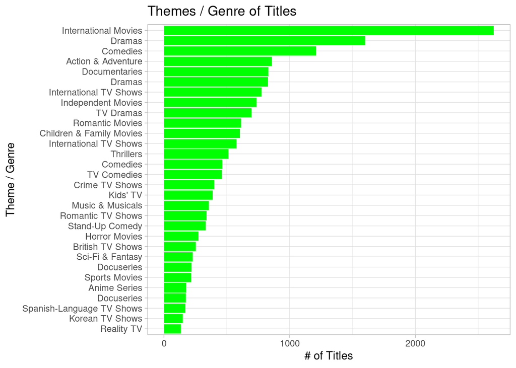

```r
netflix %>%
 select(listed_in) %>%
 mutate(listed_in = str_split(listed_in,',')) %>%
 unnest(listed_in) %>%
 group_by(listed_in) %>%
 count() %>%
 arrange(desc(n)) %>%
 head(30) %>%
 ggplot() + geom_col(aes(y = reorder(listed_in,n), x = n), fill = "green") +
 labs(title = 'Themes / Genre of Titles',
     x = '# of Titles',
     y = 'Theme / Genre') +
    theme_light()
```

The most of content on Netflix consists of International Movies.

```r
desc_words_m <- netflix %>% select(type, show_id, description) %>%
  filter(type == "Movie") %>%
    unnest_tokens(word, description) %>%
    anti_join(stop_words)
```

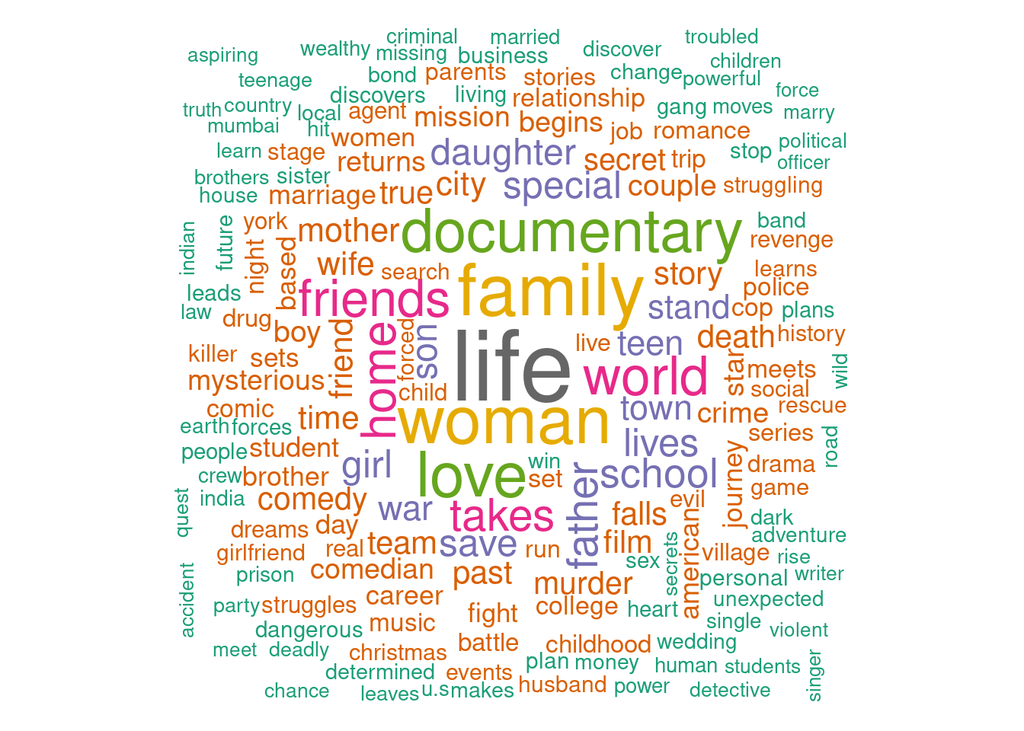

```r
count_word <- desc_words_m %>%
   count(word, sort = TRUE)


wordcloud(words = count_word$word,
          freq = count_word$n,
          min.freq = 50,
          max.words = nrow(count_word),
          random.order = FALSE,
          rot.per = 0.1,
          colors = brewer.pal(8, "Dark2"))
```

```r
desc_words_tv <- netflix %>% select(type, show_id, description) %>%
  filter(type == "TV Show") %>%
    unnest_tokens(word, description) %>%
    anti_join(stop_words)
```

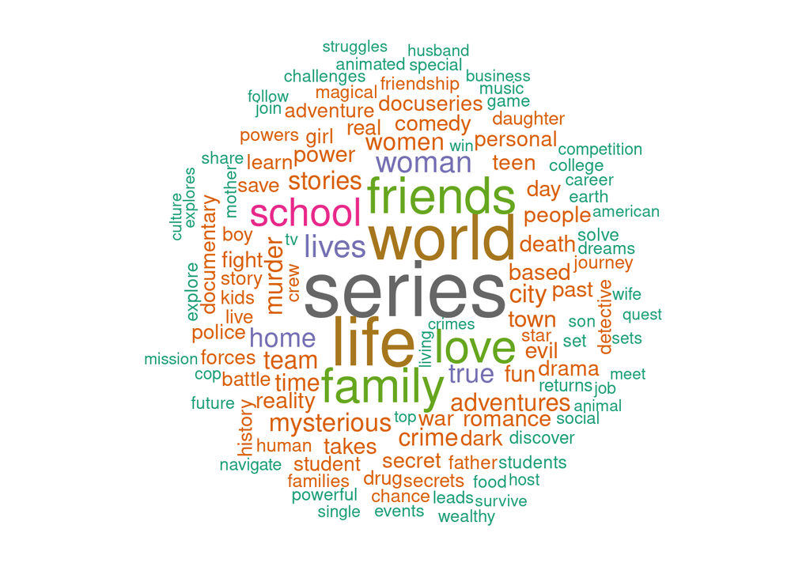

```r
count_word <- desc_words_tv %>%
   count(word, sort = TRUE)


wordcloud(words = count_word$word,
          freq = count_word$n,
          min.freq = 30,
          max.words = nrow(count_word),
          random.order = FALSE,
          rot.per = 0.1,
          colors = brewer.pal(8, "Dark2"))
```